# Introduction to Generalised Additive Models

Dimitri A Skandalis

# Motivation

Today’s topic is, how do we approach patterns in data that cannot be easily described by a known relationship? By this, we mean a linear relationship, a logarithmic, logistic growth, etc. This problem especially arises in time series. A principal advantage of parametric models is that they provide a point estimate, such as a slope or mean, that can be used to compare among e.g., treatments. How can we make comparisons without this point estimate? What if there is random variation among groups, how can this be compared if we do not have a way of parametrising it?

## Parametric and non-parametric model components

A loosely-correct expression to describe the relationship of two variables is,

$$\begin{equation}
\tag{eq.1}
g(E(y)) = \beta + \sum_j{f_j(x_j)} + \epsilon
\end{equation}$$

where the observations $y$ are related to an intercept $\beta$ and the sum of $j$ functions $f_j$ of $j$ variables $x_j$. The link function $g(\cdot)$ is the relationship between the predictors and the mean of the observations. Finally, we have some error $\epsilon$ present in our observations. The form of the error term is critical, as we will see below. A readable introduction to GAMs can be found [here](https://petolau.github.io/Analyzing-double-seasonal-time-series-with-GAM-in-R/).

A simple form of eq. 1 might be the **linear model**,

$$\begin{equation}
\tag{eq.1b}
y = \beta + m_1 \cdot x_1 + m_2 \cdot x_2
\end{equation}$$

$j=2$ but both functions of the predictors are linear, with a known number of coefficients to describe the relationship. The link function is not missing: the transformation from the scale of $y$ to the scale of the predictors is the *identity function*; we could have written $I(y)$.

The link function belongs to the realm of the **generalised models**, which we need not consider right now.

Instead, we’ll relax the assumption that the function $f_j$ are parametric: we know there may be a relationship, but it might not be possible to exactly define it ahead of time. We can fit trends to the relationship through splines, but we lose access to certain conveniences, like point estimates.

Let us consider a data set that consists of a time series of responses. We will label one of these a control, for convenience. By using synthetic data rather than data sets to demonstrate techniques, we know the underlying **generative process**. This is crucial for judging if our statistical techniques are doing what we think they’re doing. Modelling the generative process is really the essential feature of Bayesian statistics. We will be using `mgcv` to start with, which at its core is based on Bayesian modelling.

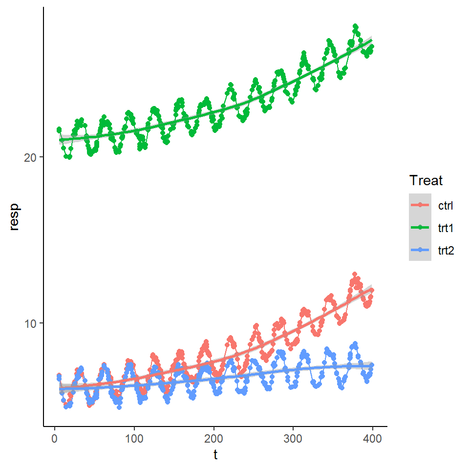

```r
set.seed(1)
n <- 400

t <- sort(runif(n, 0,n))

# autocorrelated stationary errors, see
# https://stats.stackexchange.com/questions/29239/creating-auto-correlated-random-values-in-r
ctrl <- cos(t/5) + exp(t/200) + 5 +
  stats::filter(rnorm(n,0,0.1), filter=rep(1,3), circular=TRUE)
trt1 <- cos(t/5) + exp(t/200) + 20 +
  stats::filter(rnorm(n,0,0.1), filter=rep(1,3), circular=TRUE)
trt2 <- cos(t/5) + exp(t/400) + 5 +
  stats::filter(rnorm(n,0,0.1), filter=rep(1,3), circular=TRUE)


dat <- data.frame(t = rep(t,3),
                  Treat = rep(c('ctrl','trt1','trt2'), each=n),
                  resp = c(ctrl,trt1,trt2) )

dat %>%
  ggplot( aes(x=t, y=resp, Group=Treat, col=Treat) ) +
  geom_line() +
  geom_point() +
  geom_smooth() +
  theme_classic()
```

## Fitting a single response group

The control sequence appears to differ from both treatments, but the question is, how? Let’s start by considering just the control group. We will probably know in advance which predictor variables we expect need to be modelled by a smooth relationship, which can be done by enclosing the term in `s()`. The advantage of `mgcv` is that other than this small differnece, the model specification is straightforward compared to what we’re used to in R. If we execute `mod1`, we observe that we have a single parametric term, the intercept. As an example of how this is similar to base R, we could suppressthe intercept by adding `-1`.

```r
mod1_gcv <- gam( resp ~ s(t),
                 data=filter(dat, Treat=='ctrl'),
                 method='REML' )
summary(mod1_gcv)
```

```
##
## Family: gaussian
## Link function: identity
##
## Formula:
## resp ~ s(t)
##
## Parametric coefficients:
##             Estimate Std. Error t value Pr(>|t|)
## (Intercept)  8.13097    0.03572   227.6   <2e-16 ***
## ---
## Signif. codes:  0 '***' 0.001 '**' 0.01 '*' 0.05 '.' 0.1 ' ' 1
##
## Approximate significance of smooth terms:
##        edf Ref.df     F p-value
## s(t) 4.551  5.591 427.6  <2e-16 ***
## ---
## Signif. codes:  0 '***' 0.001 '**' 0.01 '*' 0.05 '.' 0.1 ' ' 1
##
## R-sq.(adj) =  0.857   Deviance explained = 85.9%
## -REML = 441.22  Scale est. = 0.51039   n = 400
```

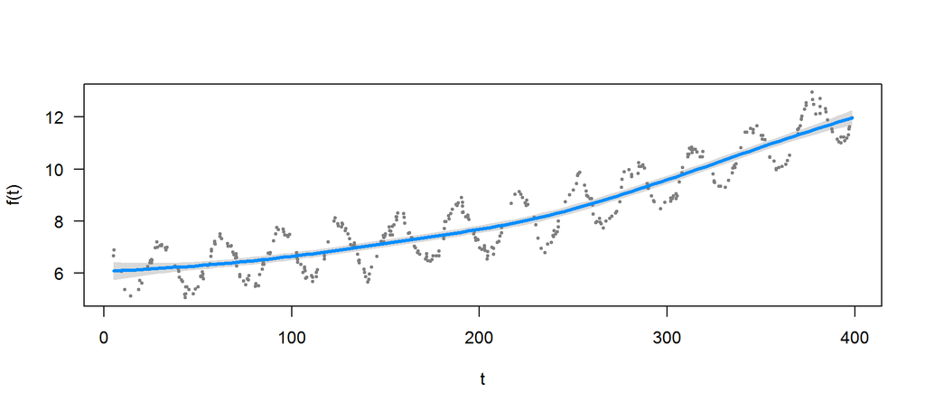

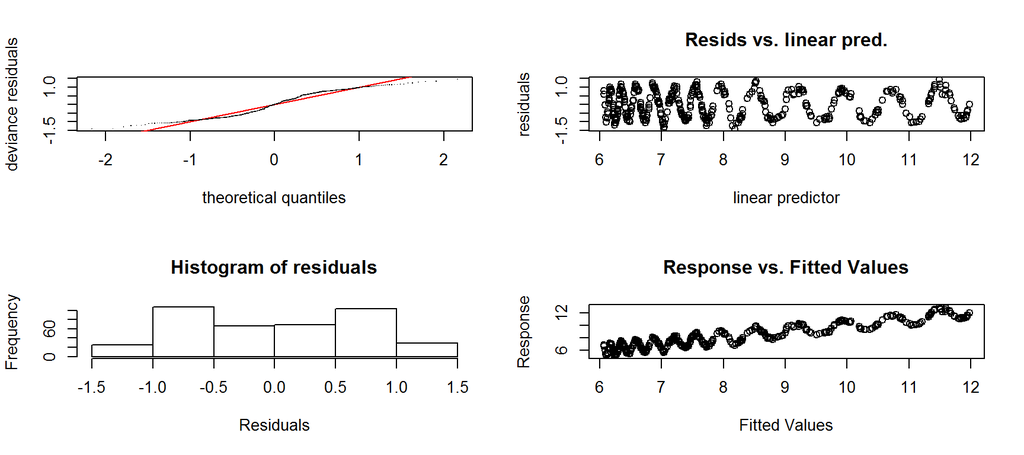

```
##
## Method: REML   Optimizer: outer newton
## full convergence after 5 iterations.
## Gradient range [-5.743388e-07,4.70292e-07]
## (score 441.2175 & scale 0.5103914).
## Hessian positive definite, eigenvalue range [1.323028,199.016].
## Model rank =  10 / 10
##
## Basis dimension (k) checking results. Low p-value (k-index<1) may
## indicate that k is too low, especially if edf is close to k'.
##
##        k'  edf k-index p-value
## s(t) 9.00 4.55    0.06  <2e-16 ***
## ---
## Signif. codes:  0 '***' 0.001 '**' 0.01 '*' 0.05 '.' 0.1 ' ' 1
```

```r
visreg(mod1_gcv); gam.check(mod1_gcv)
```

`gam()` has done surprisingly poorly, converging on an over-smoothed fit. This is visible in the diagnostic plots called by `gam.check()`. In my experience, this is very common in long time series, and has to do with the long frequency components that `gam()` attempts to fit. Try changing the number of samples `n=`, and see what happens.

It might be helpful to try using a different kind of basis for the fitting, which is done by `s(.,bs=)`. An adaptive spline basis (‘ad’) allows the degree of smoothing to change through the data set. This fits much better. However, an ostensible advantage of the spline smoothing is that smoothing in any one part of the function is informed by information found throughout the data set. So, `bs='ad'` effectively short-circuits this to fit better, possibly at the risk of overfitting.

```r
mod2_gcv <- gam( resp ~ s(t, bs='ad'),
                 data=filter(dat, Treat=='ctrl'),
                 method='GCV.Cp' )
summary(mod2_gcv)
```

```
##
## Family: gaussian
## Link function: identity
##
## Formula:
## resp ~ s(t, bs = "ad")
##
## Parametric coefficients:
##             Estimate Std. Error t value Pr(>|t|)
## (Intercept) 8.130969   0.008503   956.3   <2e-16 ***
## ---
## Signif. codes:  0 '***' 0.001 '**' 0.01 '*' 0.05 '.' 0.1 ' ' 1
##
## Approximate significance of smooth terms:
##        edf Ref.df    F p-value
## s(t) 37.94   38.6 1265  <2e-16 ***
## ---
## Signif. codes:  0 '***' 0.001 '**' 0.01 '*' 0.05 '.' 0.1 ' ' 1
##
## R-sq.(adj) =  0.992   Deviance explained = 99.3%
## GCV = 0.032037  Scale est. = 0.028918  n = 400
```

[figure not shown]

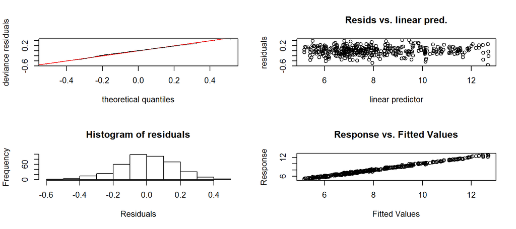

```
##
## Method: GCV   Optimizer: magic
## Smoothing parameter selection converged after 12 iterations.
## The RMS GCV score gradient at convergence was 2.709464e-07 .
## The Hessian was positive definite.
## Model rank =  40 / 40
##
## Basis dimension (k) checking results. Low p-value (k-index<1) may
## indicate that k is too low, especially if edf is close to k'.
##
##        k'  edf k-index p-value
## s(t) 39.0 37.9    0.44  <2e-16 ***
## ---
## Signif. codes:  0 '***' 0.001 '**' 0.01 '*' 0.05 '.' 0.1 ' ' 1
```

```r
par(mfrow=c(3,2))
plot(mod2_gcv,shade=TRUE, rug=TRUE, all.terms=TRUE)
gam.check(mod2_gcv)
```

# Fitting multiple response groups

Now let us return to our principal question, is there evidence that the functions diverge? There are a number of ways to deal with interactions However, `s()` can deal with factors through a special `by=` argument. `s(by=)` deals with factors depending on whether they are unordered or ordered. One smooth is fit for each of the unordered factors. It is extremely important that the parametric term be included, as described (here)[https://stats.stackexchange.com/questions/349371/gam-with-categorical-variables-interpretation] and elsewhere. Let’s see what happens when it’s omitted.

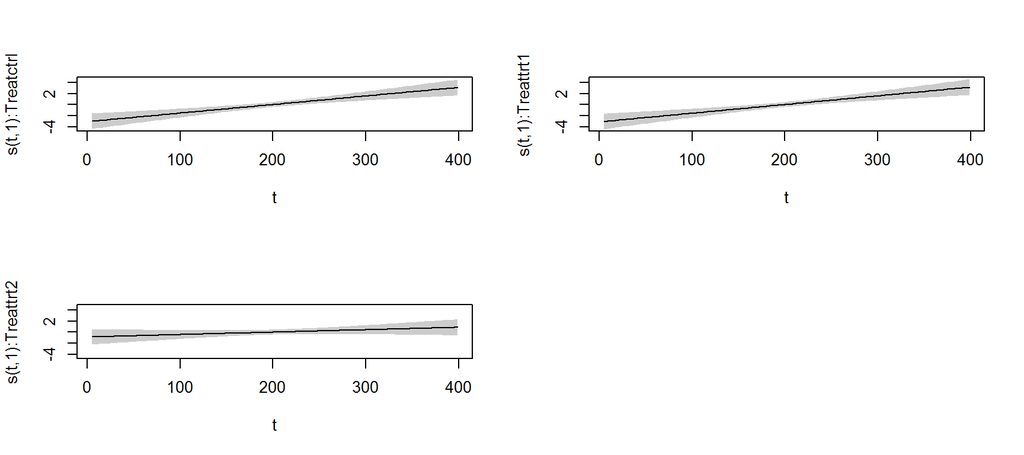

```r
mod3_bad <- gam( resp ~
                   s(t, by=Treat, bs='ad'),
                 data=dat )
mod3 <- gam( resp ~
               Treat +
               s(t, by=Treat, bs='ad'),
             data=dat )

par(mfrow=c(2,2))
plot(mod3_bad, rug=FALSE, shade=TRUE, ask=FALSE, all.terms=TRUE, seWithMean=TRUE)
par(mfrow=c(2,2))
```

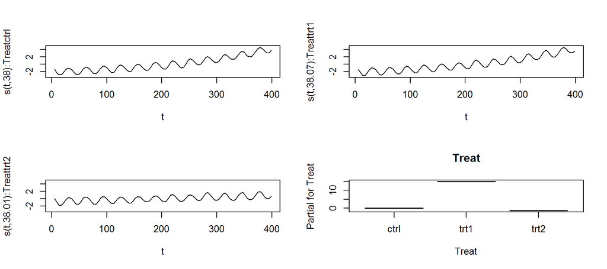

```r
plot(mod3, rug=FALSE, shade=TRUE, ask=FALSE, all.terms=TRUE, seWithMean=TRUE)
```

It is possible to estimate differences between the smooths by sampling from the posteriors, as described [here](https://www.fromthebottomoftheheap.net/2017/10/10/difference-splines-i/). Because one of our groups is a control to which we wish to compare, we may take a simpler different [approach](https://www.fromthebottomoftheheap.net/2017/12/14/difference-splines-ii/).

In the following, the model is set up to ask two questions. First, can the differences between treatments be explained **parametrically**, i.e., an intercept difference? It is crucial that we answer this question first, by parsimony, because we should not invoke more complicated effects until necessary. Second, we ask if additional non-parametric differences are necessary to account for the difference among treatments? We designate our control as a reference smooth, and rather than calculating smooths for each treatment, we calculate *difference smooths*. The difference smooths account for apparent variation among treatments after we’ve centered the trends. Note that centering is done at the mean, not at `x=0`.

```r
dat_ord <- dat %>%
  mutate(Treat=factor(Treat, ordered=TRUE, levels=c('ctrl','trt1','trt2')))

mod4 <- gam( resp ~
               Treat +
               s(t, bs='ad') +
               s(t, by=Treat, bs='ad', m=1),
             method='REML',
             data=dat_ord )

summary(mod4)
```

```
##
## Family: gaussian
## Link function: identity
##
## Formula:
## resp ~ Treat + s(t, bs = "ad") + s(t, by = Treat, bs = "ad",
##     m = 1)
##
## Parametric coefficients:
##               Estimate Std. Error t value Pr(>|t|)
## (Intercept)  12.648806   0.004954  2553.0   <2e-16 ***
## Treat.L      -1.013128   0.008581  -118.1   <2e-16 ***
## Treat.Q     -12.821184   0.008581 -1494.1   <2e-16 ***
## ---
## Signif. codes:  0 '***' 0.001 '**' 0.01 '*' 0.05 '.' 0.1 ' ' 1
##
## Approximate significance of smooth terms:
##                   edf Ref.df        F p-value
## s(t)           38.681 38.972 1559.398  <2e-16 ***
## s(t):Treattrt1  2.217  2.768    2.102  0.0784 .
## s(t):Treattrt2  9.593 11.807  952.797  <2e-16 ***
## ---
## Signif. codes:  0 '***' 0.001 '**' 0.01 '*' 0.05 '.' 0.1 ' ' 1
##
## R-sq.(adj) =  0.999   Deviance explained =  100%
## -REML = -226.18  Scale est. = 0.029456  n = 1200
```

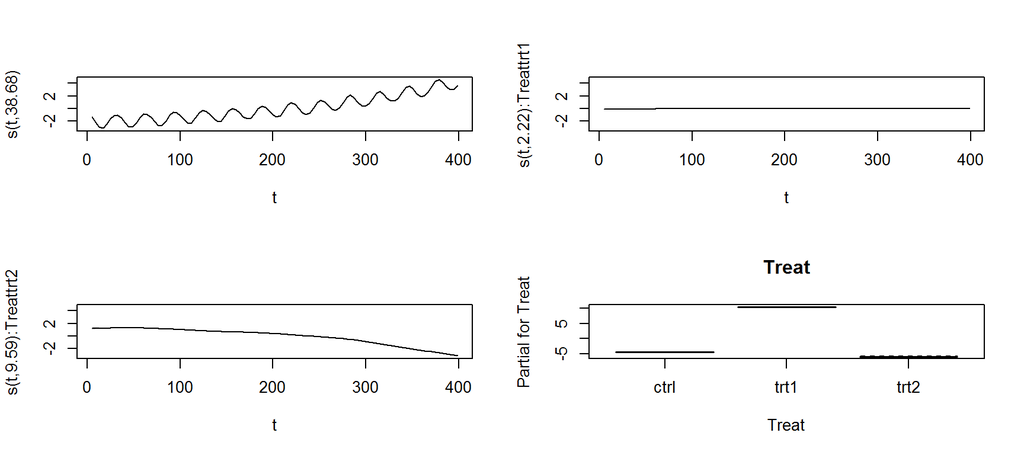

```r
par(mfrow=c(2,2))
plot(mod4, rug=FALSE, shade=TRUE, ask=FALSE, all.terms=TRUE, seWithMean=TRUE)
```

## Random effects

The ‘wiggliness’ of the smooth is a random effect. This fact can be exploited to easily incorporate quite sophisticated random effects terms.

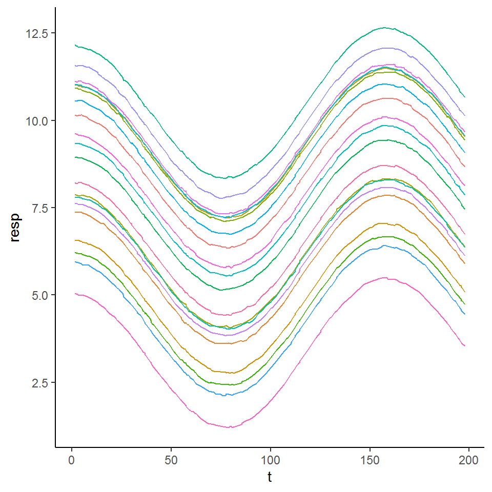

```r
set.seed(2)
n <- 200

t <- sort(runif(n, 0,n))
nind <- 20

tserr <- function(n)
  stats::filter(rnorm(n,0,0.01), filter=rep(1,3), circular=TRUE)

# autocorrelated stationary errors
func <- function(t, int=rnorm(1,5,2), coef1=rnorm(1,5,2), coef2=rnorm(1,400,10))
{
  o <- coef1*cos(t/25) + exp(t/coef2) + int + unlist(tserr(n))
  attributes(o) <- NULL
  o
}

dat_re_int <-
  ldply( 1:nind, function(i)
    data.frame(Ind=as.character(rep(i,n)), t=t, resp=func(t, coef1=2,coef2=400)) )

dat_re_int %>%
  ggplot( aes(x=t, y=resp, Group=Ind, col=Ind) ) +
  geom_line() +
  theme_classic() +
  theme(legend.position='none')
```

We’ll start by examining random intercepts. In the following, look at the summary output for smooth terms. Try setting a constant intercept for the random effects in the previous code.

```r
mod5 <- gam( resp ~
               s(t) +
               s(Ind,bs='re'),
             method='REML',
             data=dat_re_int )

summary(mod5)
```

```
##
## Family: gaussian
## Link function: identity
##
## Formula:
## resp ~ s(t) + s(Ind, bs = "re")
##
## Parametric coefficients:
##             Estimate Std. Error t value Pr(>|t|)
## (Intercept)   7.4515     0.4704   15.84   <2e-16 ***
## ---
## Signif. codes:  0 '***' 0.001 '**' 0.01 '*' 0.05 '.' 0.1 ' ' 1
##
## Approximate significance of smooth terms:
##        edf Ref.df       F p-value
## s(t)     9      9 1956367  <2e-16 ***
## s(Ind)  19     19 1904805  <2e-16 ***
## ---
## Signif. codes:  0 '***' 0.001 '**' 0.01 '*' 0.05 '.' 0.1 ' ' 1
##
## R-sq.(adj) =      1   Deviance explained =  100%
## -REML = -9472.9  Scale est. = 0.00046471  n = 4000
```

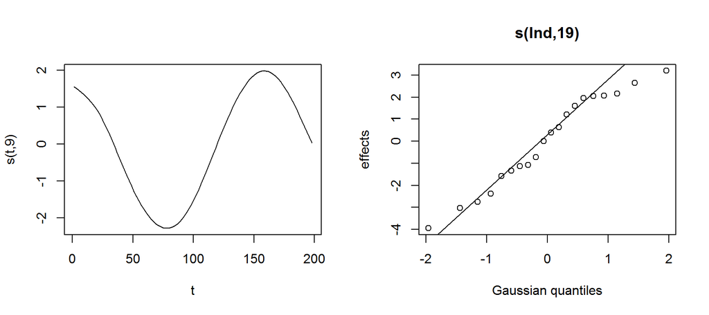

```r
par(mfrow=c(1,2))
plot(mod5, rug=FALSE, shade=TRUE, ask=FALSE, all.terms=TRUE, seWithMean=TRUE)
```

It is also possible to specify random slopes.

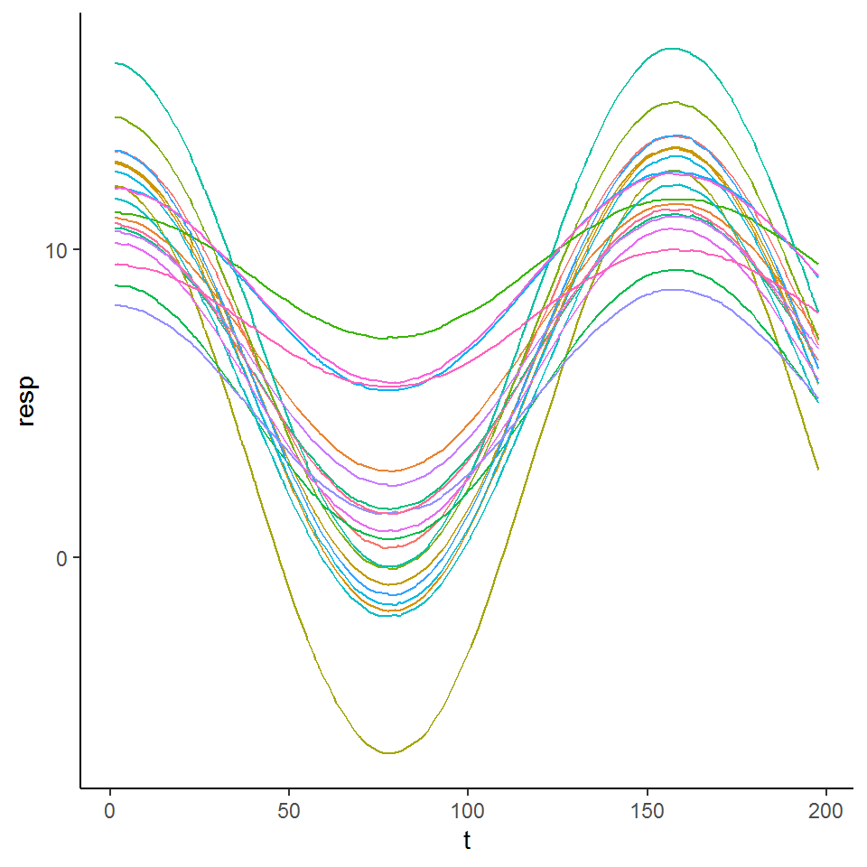

```r
dat_re_slp <-
  ldply( 1:nind, function(i)
    data.frame(Ind=as.character(rep(i,n)), t=t, resp=func(t)) )

dat_re_slp %>%
  ggplot( aes(x=t, y=resp, Group=Ind, col=Ind) ) +
  geom_line() +
  theme_classic() +
  theme(legend.position='none')
```

```r
mod6 <- gam( resp ~
               s(t) +
               s(Ind,bs='re') +
               s(t,Ind,bs='re'),
             method='ML',
             data=dat_re_slp )

summary(mod6)
```

```
##
## Family: gaussian
## Link function: identity
##
## Formula:
## resp ~ s(t) + s(Ind, bs = "re") + s(t, Ind, bs = "re")
##
## Parametric coefficients:
##             Estimate Std. Error t value Pr(>|t|)
## (Intercept)   7.1381     0.3802   18.77   <2e-16 ***
## ---
## Signif. codes:  0 '***' 0.001 '**' 0.01 '*' 0.05 '.' 0.1 ' ' 1
##
## Approximate significance of smooth terms:
##             edf Ref.df    F p-value
## s(t)      8.917  8.998 3126  <2e-16 ***
## s(Ind)   18.779 19.000 6858  <2e-16 ***
## s(t,Ind) 17.057 19.000 5742  <2e-16 ***
## ---
## Signif. codes:  0 '***' 0.001 '**' 0.01 '*' 0.05 '.' 0.1 ' ' 1
##
## R-sq.(adj) =  0.896   Deviance explained = 89.7%
## -ML = 7057.6  Scale est. = 1.8939    n = 4000
```

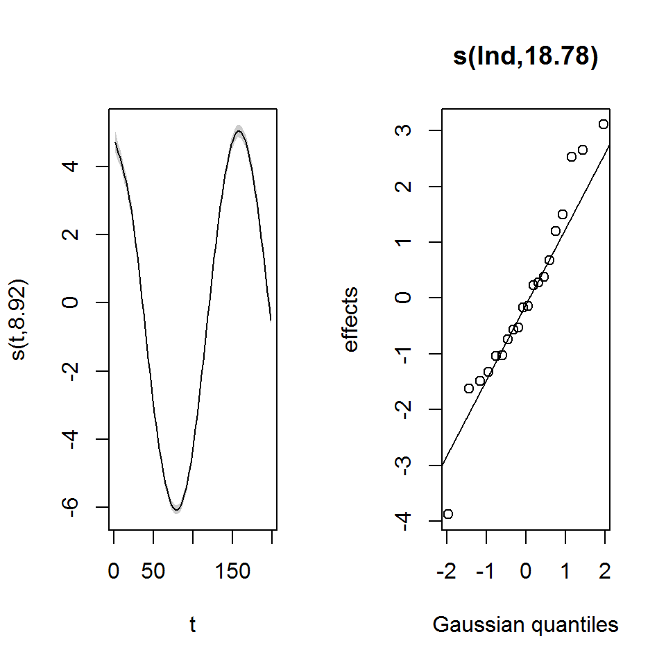

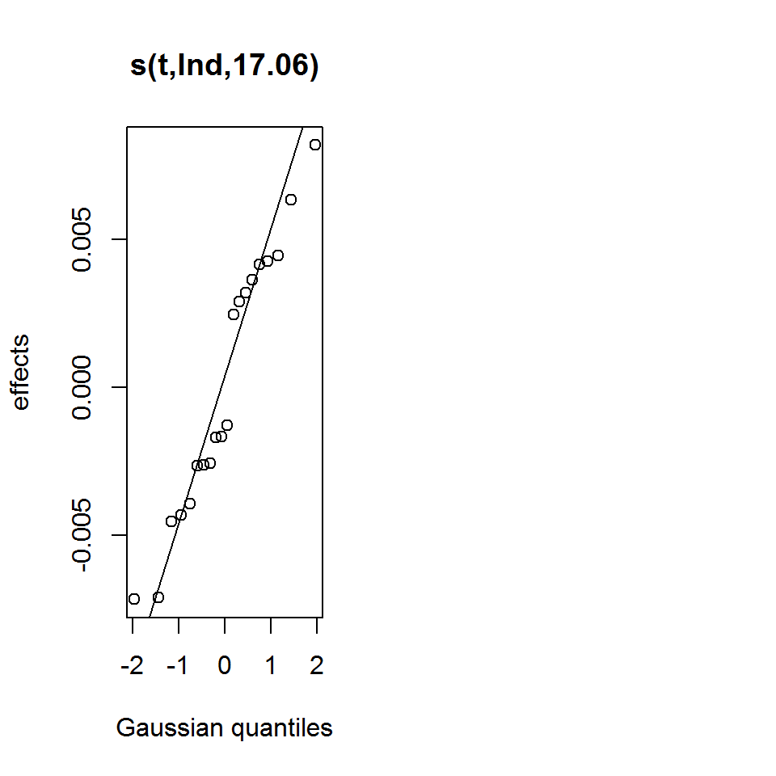

```r
par(mfrow=c(1,2))
plot(mod6, rug=FALSE, shade=TRUE, ask=FALSE, all.terms=TRUE, seWithMean=TRUE)
```

Finally, what if the non-parametric function is *itself* the random effect? This can be handled by a special type of factor-smooth basis set, `bs='fs'`. This is extremely powerful, but extremely slow!

```r
# reduce number of individuals to speed convergence
nind <- 6
dat_re_slp <-
  ldply( 1:nind, function(i)
    data.frame(Ind=as.character(rep(i,n)), t=t, resp=func(t)) )

mod7 <- gam( resp ~
               s(t) +
               s(t,Ind,bs='fs'),
             method='REML',
             data=dat_re_slp )

summary(mod7)
```

```
##
## Family: gaussian
## Link function: identity
##
## Formula:
## resp ~ s(t) + s(t, Ind, bs = "fs")
##
## Parametric coefficients:
##             Estimate Std. Error t value Pr(>|t|)
## (Intercept)    7.369      2.408   3.061  0.00226 **
## ---
## Signif. codes:  0 '***' 0.001 '**' 0.01 '*' 0.05 '.' 0.1 ' ' 1
##
## Approximate significance of smooth terms:
##             edf Ref.df       F p-value
## s(t)      8.893  8.893    74.2  <2e-16 ***
## s(t,Ind) 50.031 58.000 42888.6  <2e-16 ***
## ---
## Signif. codes:  0 '***' 0.001 '**' 0.01 '*' 0.05 '.' 0.1 ' ' 1
##
## R-sq.(adj) =      1   Deviance explained =  100%
## -REML = -1773.8  Scale est. = 0.0018973  n = 1200
```

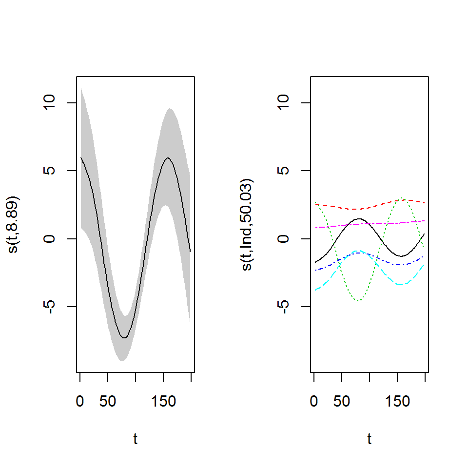

```r
par(mfrow=c(1,2))
plot(mod7, rug=FALSE, shade=TRUE, ask=FALSE, all.terms=TRUE, seWithMean=TRUE)
```

This has been a brief overview of some features of specifying smooth relationships in a non-parametric way. It is straightforward to generalise this method to other types of response distributions by specifying `family=`. Even more flexibility can be found in `brms`, at a significant computational burden and increased challenge of model validation. `brms` borrows `mgcv`’s notation, with the exception of the random effects specification (don’t try it!).